# act_report

## Report: act_report

- Create a **250-word-minimum written report** called "act_report.pdf" or "act_report.html" that communicates the insights and displays the visualization(s) produced from your wrangled data. This is to be framed as an external document, like a blog post or magazine article, for example.

## Analyzing and Visualizing Data

After wrangling the dataset, in this section, we will analyze and visualize it.

**We'll analyze those points:**

> - The most source used for the tweets.
> - The most attributed numerator rating.
> - The distribution of ineteraction with the twitter account post's over time.
> - **The distribution of tweets over years.**

**A visual presentation of the different sources used for the tweets.**

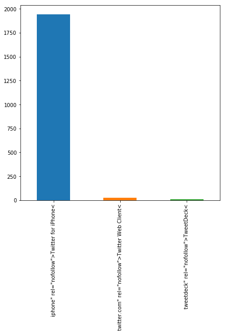

**We notice that they are 3 sources used: "Iphone, Twitter Web,and tweetdeck"**

### The most used rating:

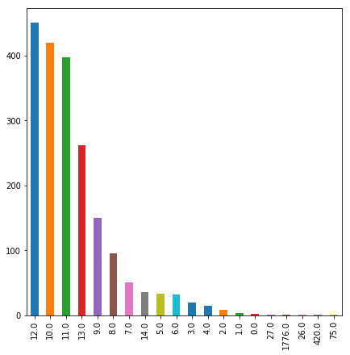

> -**The most attributed rating is 12.**

> -**The interaction over time**

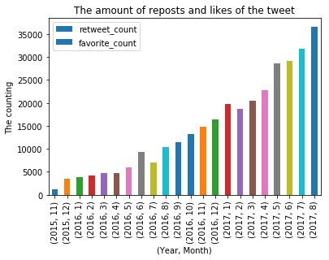

**From 2015 to 2017, the interaction (reposts and likes) are growing. The WeRateDogs Twitter account content has more of attention over time from other users**

**The distribution of tweets over years.**

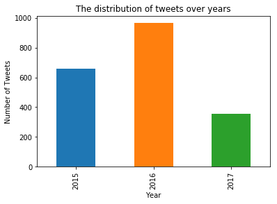

**In 2016, the twitter account WeRateDogs has published the most tweets.**

**Insights:**:

> - We notice that they are 3 sources used: "Iphone, Twitter Web,and tweetdeck", the most source used is Iphone.
> - The most attributed rating is 12.
> - The visual presentation of the interaction over time, make an insight about the The WeRateDogs Twitter account interaction. From 2015 to 2017, the interaction (reposts and likes) are growing. The WeRateDogs Twitter account content has more of attention over time from other users.
> - The WeRateDogs twitter account made a lot of posts "tweets" in 2016.